# BCB420 A2: Differential Gene Expression and Preliminary ORA

Kara Han

2022-03-19

# Introduction: A1 Results Summary

For Assignment 1, I selected the GEO dataset with accession number GSE166605: RNA-sequencing analysis of effect of miR-155 overexpression in human CD14+ monocytes (Olsson et al. 2021).

MicroRNAs (miRs) are essential regulators for pro-inflammatory effector functions of myeloid cells and miR dysfunction is implicated in rheumatoid arthritis (RA). The study investigates two groups, miR-155 and negative control, in 5 donors to understand the effect of miR-155 overexpression in human CD14+ monocytes.

The raw count data contains a total of 60603 genes. Genes that have low counts were removed from the raw count data and normalization was subsequently performed using the `edgeR` package. The multidimensional scaling (MDS) plot of the post-normalization data showed a clear separation of the samples in the two groups, suggesting that miR-155 groups and negaitve control groups have different behaviours across their counts and differential expressions. The Ensembl gene IDs in the original count data were mapped to HGNC symbols to create the final normalized dataset. The final coverage of the miR-155 dataset is 13003 genes along with their Ensembl gene IDs, HGNC symbols, and normalized counts in 5 donors (10 samples).

# Differential Gene Expression Analysis

First, I’ll load the required packages and read in the original and normalized count datasets.

```r
# The code in this report is adapted from Dr. Ruth Isserlin's Lecture 6-7 slides (Isserlin, 2022).

# Install required packages
if (!require("BiocManager", quietly = TRUE)) {
  install.packages("BiocManager")
}

if (!requireNamespace("biomaRt", quietly = TRUE)) {
  BiocManager::install("biomaRt")
}

if (!requireNamespace("GEOquery", quietly = TRUE)) {
  BiocManager::install("GEOquery")
}

if (!requireNamespace("edgeR", quietly = TRUE)) {
  BiocManager::install("edgeR")
}

if (!requireNamespace("limma", quietly = TRUE)) {
  BiocManager::install("limma")
}

if (!requireNamespace("Biobase", quietly = TRUE)) {
  BiocManager::install("Biobase")
}

if (!require("dplyr", quietly = TRUE)) {
  install.packages("dplyr")
}

if (!require("circlize", quietly = TRUE)) {
  install.packages("circlize")
}

if (!require("gprofiler2", quietly = TRUE)) {
  install.packages("gprofiler2")
}

if (!require("plotfunctions", quietly = TRUE)) {
  install.packages("plotfunctions")
}
```

```r
# A way to download the dataset only when necessary instead of re-downloading it every time the Notebook is run
gseDirectory <- file.path(getwd(), "GSE166605")
if (!file.exists(gseDirectory)) {
  # Get the supplementary files from GEO
  suppFiles <- GEOquery::getGEOSuppFiles("GSE166605")
  # There is only one supplementary file
  fnames <- rownames(suppFiles)
} else {
  fnames <- file.path(gseDirectory, "GSE166605_D1-5_Neg_C_miR_155_RAW_counts.txt.gz")
}

# Read in the original count data
expData <- read.delim(fnames[1], header = TRUE, check.names = FALSE)
head(expData)
```

|  | GeneID | Gene name | D1 CD14 Neg C | D1 CD14 miR-155 | D2 CD14 Neg C | D2 CD14 miR-155 | D3 CD14 Neg C | D3 CD14 miR-155 | D4 CD14 Neg C | D4 CD14 miR-155 | D5 CD14 Neg C | D5 CD14 miR-155 |
| --- | --- | --- | --- | --- | --- | --- | --- | --- | --- | --- | --- | --- |
| 1 | ENSG00000223972.5 | DDX11L1 | 0 | 0 | 1 | 0 | 0 | 0 | 0 | 0 | 0 | 0 |
| 2 | ENSG00000227232.5 | WASH7P | 429 | 256 | 152 | 137 | 107 | 129 | 127 | 73 | 140 | 124 |
| 3 | ENSG00000278267.1 | MIR6859-1 | 21 | 26 | 6 | 6 | 13 | 6 | 5 | 7 | 15 | 10 |
| 4 | ENSG00000243485.5 | MIR1302-2HG | 0 | 0 | 0 | 0 | 0 | 0 | 0 | 0 | 0 | 0 |
| 5 | ENSG00000284332.1 | MIR1302-2 | 0 | 0 | 0 | 0 | 0 | 0 | 0 | 0 | 0 | 0 |
| 6 | ENSG00000237613.2 | FAM138A | 0 | 0 | 0 | 0 | 0 | 0 | 0 | 0 | 0 | 0 |

```r
# Read in the normalized count data
normalizedCountsData <- read.table(file = file.path(getwd(), "GSE166605_normalized_counts.txt"),
                                   header = TRUE, sep = "\t",
                                   stringsAsFactors = FALSE,
                                   check.names = FALSE)
head(normalizedCountsData)
```

|  | ensembl_gene_id | hgnc_symbol | D1 CD14 Neg C | D1 CD14 miR-155 | D2 CD14 Neg C | D2 CD14 miR-155 | D3 CD14 Neg C | D3 CD14 miR-155 | D4 CD14 Neg C | D4 CD14 miR-155 | D5 CD14 Neg C | D5 CD14 miR-155 |
| --- | --- | --- | --- | --- | --- | --- | --- | --- | --- | --- | --- | --- |
| ENSG00000000419 | ENSG00000000419 | DPM1 | 25.764642 | 24.91319 | 22.543718 | 22.45683 | 24.960068 | 26.00687 | 19.345815 | 20.576949 | 20.633024 | 18.437799 |
| ENSG00000000457 | ENSG00000000457 | SCYL3 | 10.629940 | 13.15742 | 13.568968 | 13.75967 | 12.995367 | 14.14198 | 14.577481 | 14.506940 | 14.453085 | 16.886956 |
| ENSG00000000460 | ENSG00000000460 | C1orf112 | 4.148269 | 5.42574 | 5.377727 | 5.88464 | 5.915133 | 6.71145 | 5.211109 | 5.077429 | 6.678322 | 6.341224 |
| ENSG00000000938 | ENSG00000000938 | FGR | 284.253678 | 538.18824 | 411.057818 | 471.11738 | 323.046911 | 432.92848 | 319.955263 | 284.908662 | 318.632373 | 318.715452 |
| ENSG00000001036 | ENSG00000001036 | FUCA2 | 37.269608 | 40.78348 | 48.363933 | 50.01944 | 41.719611 | 50.89516 | 29.870211 | 32.946024 | 46.515675 | 43.733770 |
| ENSG00000001084 | ENSG00000001084 | GCLC | 47.056931 | 47.79173 | 91.599437 | 125.22168 | 141.739129 | 163.95114 | 60.421613 | 71.771176 | 54.788820 | 56.933167 |

## Data Visualization

Let’s use the multidimensional scaling (MDS) plot to decide which factors to include in our model.

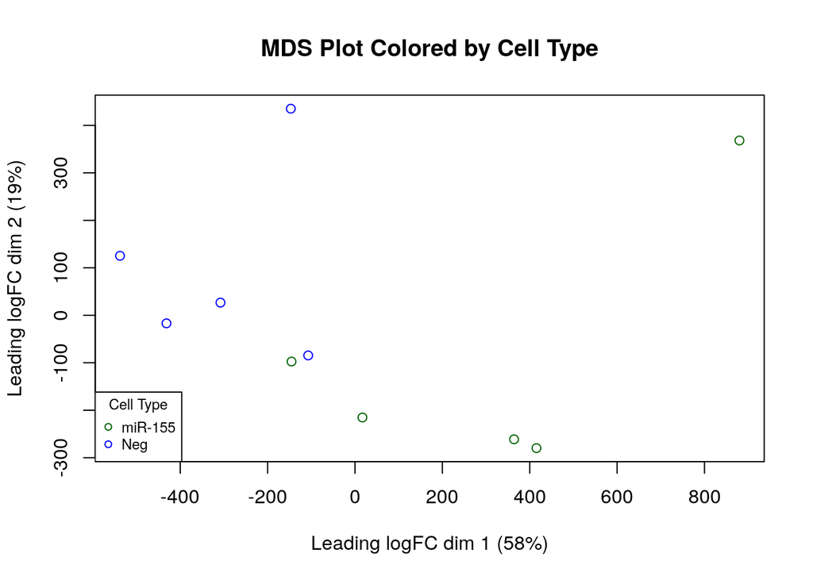

```r
# Translate raw counts into counts per million (CPM)
cpms <- edgeR::cpm(expData[, 3:12])
rownames(cpms) <- expData[, 1]

# Keep the genes with high enough counts
keep <- rowSums(cpms > 1) >= 5
expDataFiltered <- expData[keep, ] # 13003 observations

filteredDataMatrix <- as.matrix(expDataFiltered[, 3:12])
rownames(filteredDataMatrix) <- expDataFiltered$GeneID

# Define the cell types
# Extract the donor and cell types from the original data
samples <- data.frame(lapply(colnames(expData)[3:12],
                             FUN = function(x) {unlist(strsplit(x, split = " "))[c(1, 3)]}))
colnames(samples) <- colnames(expData)[3:12]
rownames(samples) <- c("donors", "cell_type")
samples <- data.frame(t(samples))

# Subset the normalized data to get expression values only
expressionMatrix <- as.matrix(normalizedCountsData[, c(3:ncol(normalizedCountsData))])

# MDS plot of samples, colored by cell type
mdsCellType <- limma::plotMDS(expressionMatrix,
                              pch = 1,
                              col = c("darkgreen", "blue")[factor(samples$cell_type)],
                              main = "MDS Plot Colored by Cell Type")

legend("bottomleft",
       legend = levels(factor(samples$cell_type)),
       pch = c(1),
       col = c("darkgreen", "blue"),
       title = "Cell Type",
       cex = 0.75)
```

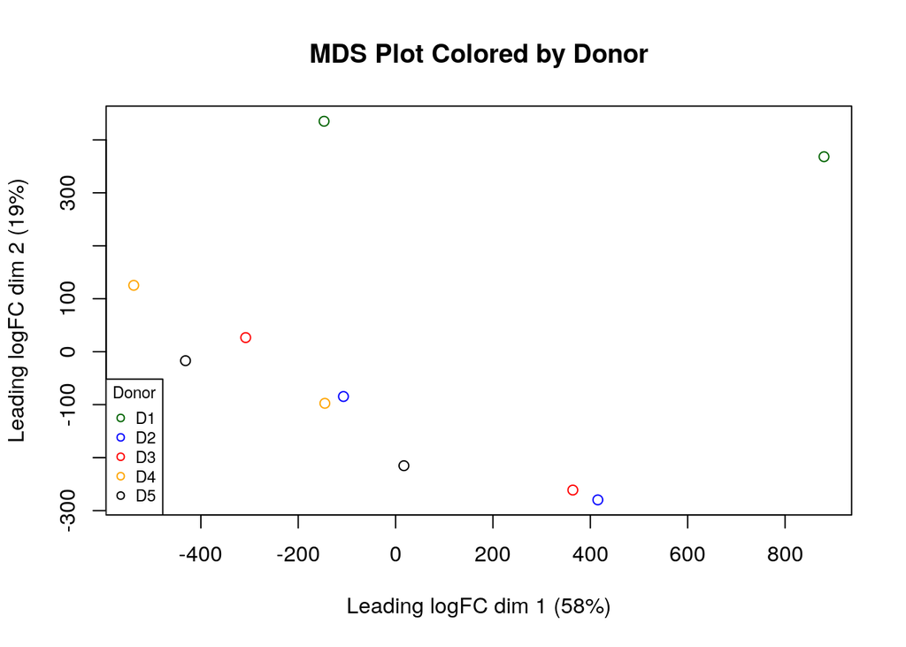

```r
# MDS plot of samples, colored by donor
mdsDonor <- limma::plotMDS(expressionMatrix,
                           pch = 1,
                           col = c("darkgreen", "blue", "red", "orange", "black")[factor(samples$donors)],
                           main = "MDS Plot Colored by Donor")

legend("bottomleft",
       legend = levels(factor(samples$donors)),
       pch = c(1),
       col = c("darkgreen", "blue", "red", "orange", "black"),
       title = "Donor",
       cex = 0.75)
```

From the MDS plot colored by cell type, we see that there is a clear separation between the cell types, suggesting the dissimilarity between miR-155 positive and negative groups.

As such, we’ll develop two models: one only with cell type as the factor and the other with both cell type and donor as the factors with the `limma` package.

## P-Value & Multiple Hypothesis Correction

In the code below, we create two linear models: one with cell type as the only factor, and the other with donor variability added.

```r
# Create a linear model with data defined by cell type only
simpleModelDesign <- model.matrix(~ samples$cell_type)
head(simpleModelDesign)
```

```
##   (Intercept) samples$cell_typeNeg
## 1           1                    1
## 2           1                    0
## 3           1                    1
## 4           1                    0
## 5           1                    1
## 6           1                    0
```

```r
# Use the heatmapMatrix from earlier to create the data matrix
minimalSet <- Biobase::ExpressionSet(assayData = as.matrix(expressionMatrix))

# Fit the data
fit <- limma::lmFit(minimalSet, simpleModelDesign)

# Use empirical Bayes to compute differential expression
# Use trend = TRUE for RNA-seq data
fit2 <- limma::eBayes(fit, trend = TRUE)

# Find the top fit
# Use Benjamini-Hochberg for multiple hypothesis correction
topfit <- limma::topTable(fit2,
                          coef = ncol(simpleModelDesign),
                          adjust.method = "BH",
                          number = nrow(expressionMatrix))

# Merge the top fit data with HGNC symbols
simpleModelOutput <- merge(normalizedCountsData[, c(1:2)],
                           topfit,
                           by.x = 1,
                           by.y = 0,
                           all.y = TRUE)

# Sort the output by p-values
simpleModelOutput <- simpleModelOutput[order(simpleModelOutput$P.Value), ]
head(simpleModelOutput)
```

|  | ensembl_gene_id | hgnc_symbol | logFC | AveExpr | t | P.Value | adj.P.Val | B |
| --- | --- | --- | --- | --- | --- | --- | --- | --- |
| 4696 | ENSG00000134326 | CMPK2 | -302.9814 | 166.5557 | -18.42194 | 4.224626e-09 | 3.954176e-05 | -0.6218500 |
| 5241 | ENSG00000138646 | HERC5 | -391.5408 | 219.5053 | -17.75061 | 6.081944e-09 | 3.954176e-05 | -0.6366804 |
| 3085 | ENSG00000115267 | IFIH1 | -382.8694 | 246.0158 | -14.13034 | 5.599247e-08 | 2.426900e-04 | -0.7527331 |
| 2742 | ENSG00000111335 | OAS2 | -935.3264 | 556.8332 | -12.97226 | 1.273478e-07 | 3.433826e-04 | -0.8093789 |
| 544 | ENSG00000055332 | EIF2AK2 | -279.0067 | 199.2401 | -12.92330 | 1.320398e-07 | 3.433826e-04 | -0.8120748 |
| 4485 | ENSG00000132274 | TRIM22 | -577.4093 | 445.5321 | -12.40090 | 1.957679e-07 | 4.242617e-04 | -0.8425991 |

```r
# Number of genes that pass the threshold p-value < 0.05
length(which(simpleModelOutput$P.Value < 0.05))
```

```
## [1] 3280
```

```r
# Number of genes that pass correction
length(which(simpleModelOutput$adj.P.Val < 0.05))
```

```
## [1] 734
```

```r
# A more complex model that accounts for donor variability
donorModelDesign <- model.matrix(~ samples$donors + samples$cell_type)
head(donorModelDesign)
```

```
##   (Intercept) samples$donorsD2 samples$donorsD3 samples$donorsD4
## 1           1                0                0                0
## 2           1                0                0                0
## 3           1                1                0                0
## 4           1                1                0                0
## 5           1                0                1                0
## 6           1                0                1                0
##   samples$donorsD5 samples$cell_typeNeg
## 1                0                    1
## 2                0                    0
## 3                0                    1
## 4                0                    0
## 5                0                    1
## 6                0                    0
```

```r
# Fit the data
fitDonor <- limma::lmFit(minimalSet, donorModelDesign)

# Use empirical Bayes to compute differential expression
# Use trend = TRUE for RNA-seq data
fit2Donor <- limma::eBayes(fitDonor, trend = TRUE)

# Find the top fit
# Use Benjamini-Hochberg for multiple hypothesis correction
topfitDonor <- limma::topTable(fit2Donor,
                               coef = ncol(donorModelDesign),
                               adjust.method = "BH",
                               number = nrow(expressionMatrix))

# Merge the top fit data with HGNC symbols
donorModelOutput <- merge(normalizedCountsData[, c(1:2)],
                          topfitDonor,
                          by.x = 1,
                          by.y = 0,
                          all.y = TRUE)
# Order the result by p-values
donorModelOutput <- donorModelOutput[order(donorModelOutput$P.Value), ]
head(donorModelOutput)
```

|  | ensembl_gene_id | hgnc_symbol | logFC | AveExpr | t | P.Value | adj.P.Val | B |
| --- | --- | --- | --- | --- | --- | --- | --- | --- |
| 1482 | ENSG00000096968 | JAK2 | -98.52852 | 128.0826 | -34.70645 | 4.555906e-08 | 0.0005924045 | 0.2980908 |
| 7231 | ENSG00000163565 | IFI16 | -168.19219 | 202.2647 | -26.04145 | 2.470846e-07 | 0.0016064206 | 0.2430276 |
| 8527 | ENSG00000173193 | PARP14 | -975.34395 | 694.6218 | -22.98969 | 5.135396e-07 | 0.0020600904 | 0.2080347 |
| 4696 | ENSG00000134326 | CMPK2 | -302.98139 | 166.5557 | -20.83960 | 9.127225e-07 | 0.0020600904 | 0.1741269 |
| 11835 | ENSG00000253729 | PRKDC | 60.97649 | 108.0645 | 20.51756 | 9.997794e-07 | 0.0020600904 | 0.1681616 |
| 3142 | ENSG00000115738 | ID2 | 68.45817 | 129.5703 | 20.24158 | 1.082169e-06 | 0.0020600904 | 0.1628344 |

```r
# Number of genes that pass the threshold p-value < 0.05
length(which(donorModelOutput$P.Value < 0.05))
```

```
## [1] 5953
```

```r
# Number of genes that pass correction
length(which(donorModelOutput$adj.P.Val < 0.05))
```

```
## [1] 3523
```

We’ll use a volcano plot to demonstrate the amount of differentially expressed genes.

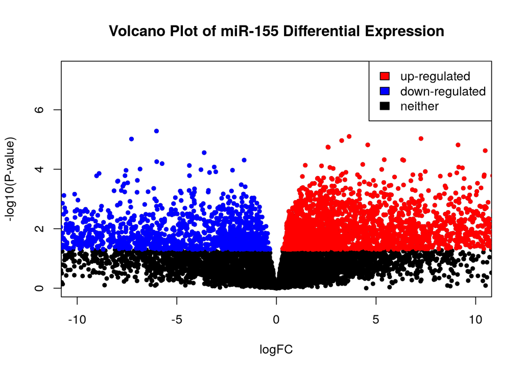

```r
# Plot all the differential expression values
plot(donorModelOutput$logFC, -log10(donorModelOutput$P.Value), pch = 20,
     main = "Volcano Plot of miR-155 Differential Expression", xlim = c(-10, 10),
     xlab = "logFC", ylab = "-log10(P-value)")

# Subset the upregulated genes and colour them as red
upregulated <- donorModelOutput[which(donorModelOutput$P.Value < 0.05 & donorModelOutput$logFC > 0), ]
with(upregulated, points(logFC, -log10(P.Value), pch = 20, col = "red"))

# Subset the downregulated genes and colour them as blue
downregulated <- donorModelOutput[which(donorModelOutput$P.Value < 0.05 & donorModelOutput$logFC < 0), ]
with(downregulated, points(logFC, -log10(P.Value), pch = 20, col = "blue"))

legend("topright",
       legend = c("up-regulated", "down-regulated", "neither"),
       fill = c("red","blue", "black"),
       cex = 1)
```

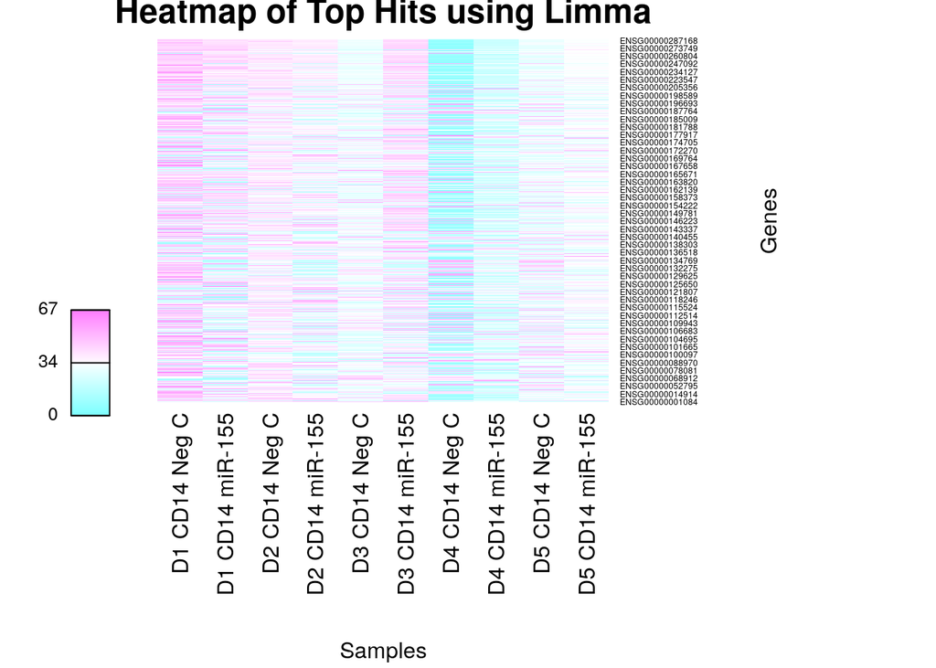

```r
# Find the significantly expressed genes
topHits <- donorModelOutput$ensembl_gene_id[donorModelOutput$P.Value < 0.05]

# Highlight the top hits
heatmapMatrixTopHits <- scale(expressionMatrix[which(rownames(expressionMatrix) %in% topHits), ])

# Create the heatmap for the top hits
topHitsHeatmap <- heatmap(as.matrix(heatmapMatrixTopHits),
                          Rowv = NA,
                          Colv = NA,
                          col = cm.colors(256),
                          margins = c(12, 8),
                          main = "Heatmap of Top Hits using Limma",
                          xlab = "Samples",
                          ylab = "Genes",
                          scale = "row")
# Add a legend
plotfunctions::gradientLegend(valRange = c(min(heatmapMatrixTopHits), max(heatmapMatrixTopHits)),
               color = "cm",
               pos = 0.4,
               side = 2,
               dec = 0)
```

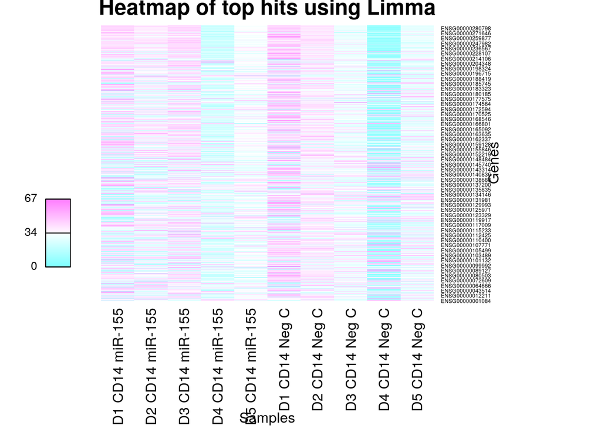

```r
# Grouping the samples for each experimental condition (miR-155 or negative control) together
heatmapTopHitsPosNeg <- heatmapMatrixTopHits[, c(grep(colnames(heatmapMatrixTopHits), pattern = "*miR-155"),
                                                 grep(colnames(heatmapMatrixTopHits), pattern = "*Neg"))]

# Plot the heatmap
topHitsPosNegHeatmap <- heatmap(as.matrix(heatmapTopHitsPosNeg),
                                Rowv = NA,
                                Colv = NA,
                                col = cm.colors(256),
                                margins = c(9, 5),
                                main = "Heatmap of top hits using Limma",
                                xlab = "Samples",
                                ylab = "Genes",
                                scale = "row")

# Add a legend
plotfunctions::gradientLegend(valRange = c(min(heatmapTopHitsPosNeg), max(heatmapTopHitsPosNeg)),
               color = "cm",
               pos = 0.4,
               side = 2,
               dec = 0)
```

## Summary

# Thresholded Over-Representation Analysis

Let’s first create the thresholded up-regulated and down-regulated gene lists to be used in the over-representation analysis.

```r
# Number of genes that are up-regulated
length(which(donorModelOutput$P.Value < 0.05 & donorModelOutput$logFC > 0))
```

```
## [1] 3113
```

```r
# Number of genes that are down-regulated
length(which(donorModelOutput$P.Value < 0.05 & donorModelOutput$logFC < 0))
```

```
## [1] 2840
```

```r
# The resulting rank value would be higher if the p-value is smaller
donorModelOutput[, "rank"] <- -log(donorModelOutput$P.Value, base = 10) * sign(donorModelOutput$logFC)
donorModelOutput <- donorModelOutput[order(donorModelOutput$rank), ]

# Create up-regulated gene list
upregulatedGenes <- donorModelOutput[which(donorModelOutput$P.Value < 0.05 & donorModelOutput$logFC > 0), ]

# Create down-regulated gene list
downregulatedGenes <- donorModelOutput[which(donorModelOutput$P.Value < 0.05 & donorModelOutput$logFC < 0), ]
```

Now that we have these two lists of up-regulated and down-regulated genes, we want to know whether there are any gene sets or pathways that are over-represented or under-represented in these lists. I will use `g:Profiler` to conduct the over-representation analysis.

```r
# Obtain the version of the annotation data
versionInfo <- gprofiler2::get_version_info(organism = "hsapiens")

versionDF <- as.data.frame(unlist(versionInfo$sources))
names(versionDF)[1] <- "version"
versionDF[, "annotation_data"] <- row.names(versionDF)
versionDF <- versionDF[versionDF$annotation_data %in% c("GO:BP.version", "KEGG.version", "REAC.version", "WP.version"), ]

# Reformat the annotation data version table for a clearer presentation
versionDF <- versionDF[, c(2, 1)]
versionDF$annotation_data <- c("GO:BP", "KEGG", "REAC", "WP")
row.names(versionDF) <- 1:4
head(versionDF)
```

|  | annotation_data | version |
| --- | --- | --- |
| 1 | GO:BP | annotations: BioMart\nclasses: releases/2021-12-15 |
| 2 | KEGG | KEGG FTP Release 2021-12-27 |
| 3 | REAC | annotations: BioMart\nclasses: 2022-1-3 |
| 4 | WP | 20211210 |

```r
# Conduct ORA
gostUp <- gprofiler2::gost(query = upregulatedGenes$ensembl_gene_id,
                           significant = FALSE,
                           user_threshold = 0.05,
                           correction_method = "fdr",
                           sources = c("GO:BP", "KEGG", "REAC", "WP"))
nrow(gostUp$result)
```

```
## [1] 12686
```

```r
gostDown <- gprofiler2::gost(query = downregulatedGenes$ensembl_gene_id,
                             significant = FALSE,
                             user_threshold = 0.05,
                             correction_method = "fdr",
                             sources = c("GO:BP", "KEGG", "REAC", "WP"))

nrow(gostDown$result)
```

```
## [1] 13058
```

```r
gostAll <- gprofiler2::gost(query = donorModelOutput$ensembl_gene_id,
                             significant = FALSE,
                             user_threshold = 0.05,
                             correction_method = "fdr",
                             sources = c("GO:BP", "KEGG", "REAC", "WP"))
nrow(gostAll$result)
```

```
## [1] 17520
```

There are >10,000 gene sets returned in each ORA, these include root terms that include many branches of more specific terms. We’ll control the size of the gene set to be smaller.

```r
gostUpResults <- gostUp$result[which(gostUp$result$term_size <= 200), ]
nrow(gostUpResults)
```

```
## [1] 11508
```

```r
gostDownResults <- gostDown$result[which(gostDown$result$term_size <= 200), ]
nrow(gostDownResults)
```

```
## [1] 11885
```

```r
gostAllResults <- gostAll$result[which(gostAll$result$term_size <= 200), ]
nrow(gostAllResults)
```

```
## [1] 16342
```

Let’s visualize the ORA results.

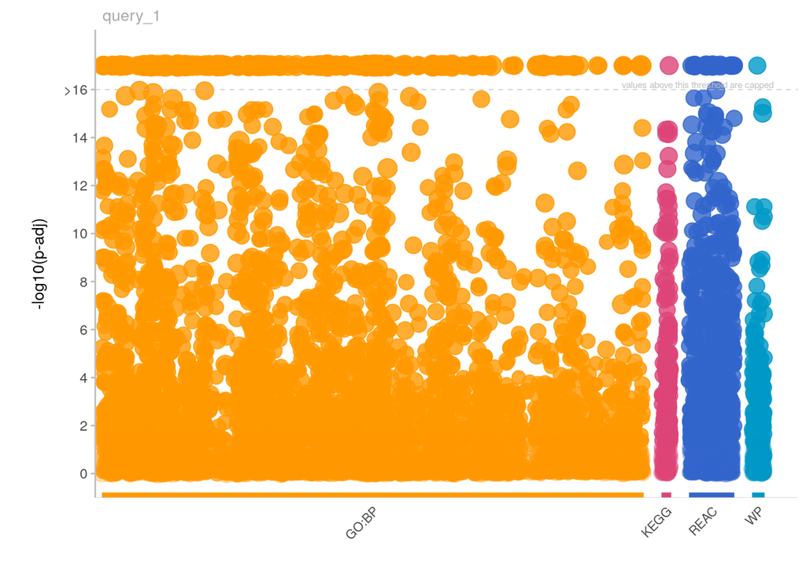

```r
gprofiler2::gostplot(gostAll, interactive = FALSE)
```

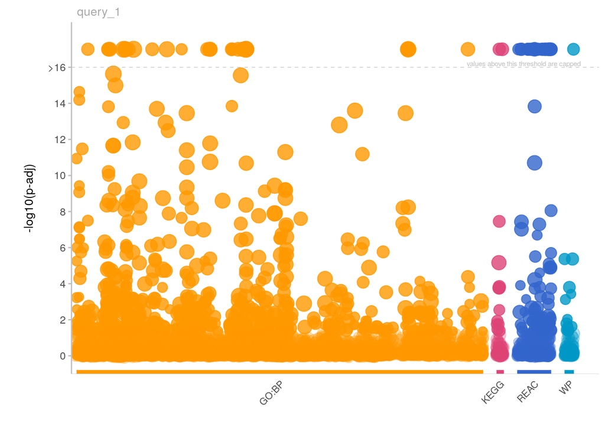

ORA Results Visualization for Upregulated Genes

```r
gprofiler2::gostplot(gostUp, interactive = FALSE)
```

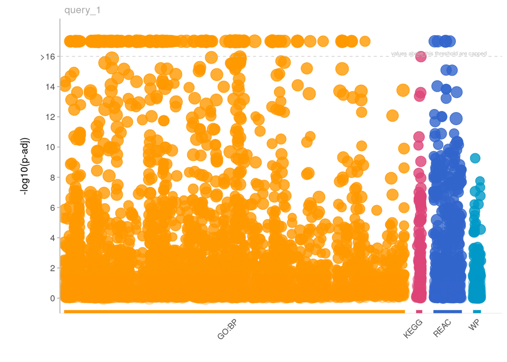

ORA Results Visualization for Downregulated Genes

```r
gprofiler2::gostplot(gostDown, interactive = FALSE)
```

```r
# Obtain the top results from each annotation data source for:
# up-regulated genes
upTopResults <- gostUpResults[which(gostUpResults$source == "GO:BP"), ][1, ]
upTopResults <- rbind(upTopResults, gostUpResults[which(gostUpResults$source == "KEGG"), ][1, ])
upTopResults <- rbind(upTopResults, gostUpResults[which(gostUpResults$source == "REAC"), ][1, ])
upTopResults <- rbind(upTopResults, gostUpResults[which(gostUpResults$source == "WP"), ][1, ])
upTopResults <- subset(upTopResults, select = c(9:11))
row.names(upTopResults) <- c(1:4)
upTopResults
```

|  | term_id | source | term_name |
| --- | --- | --- | --- |
| 1 | GO:0002181 | GO:BP | cytoplasmic translation |
| 2 | KEGG:03010 | KEGG | Ribosome |
| 3 | REAC:R-HSA-8868773 | REAC | rRNA processing in the nucleus and cytosol |
| 4 | WP:WP477 | WP | Cytoplasmic ribosomal proteins |

The up-regulated genes appear to be linked to the ribosome-mediated cytoplasmic translation of proteins. Ribosome contains rRNAs, and the top REAC result “rRNA processing” further indicates that the up-regulated genes might be involved in the processes that ensure proper ribosome formation in the cytoplasm.

```r
# down-regulated genes
downTopResults <- gostDownResults[which(gostDownResults$source == "GO:BP"), ][1, ]
downTopResults <- rbind(downTopResults, gostDownResults[which(gostDownResults$source == "KEGG"), ][1, ])
downTopResults <- rbind(downTopResults, gostDownResults[which(gostDownResults$source == "REAC"), ][1, ])
downTopResults <- rbind(downTopResults, gostDownResults[which(gostDownResults$source == "WP"), ][1, ])
downTopResults <- subset(downTopResults, select = c(9:11))
row.names(downTopResults) <- c(1:4)
downTopResults
```

|  | term_id | source | term_name |
| --- | --- | --- | --- |
| 1 | GO:0002221 | GO:BP | pattern recognition receptor signaling pathway |
| 2 | KEGG:05169 | KEGG | Epstein-Barr virus infection |
| 3 | REAC:R-HSA-913531 | REAC | Interferon Signaling |
| 4 | WP:WP183 | WP | Proteasome degradation |

Based on the results, the down-regulated genes are involved in pattern recognition receptor singaling pathway, which includes interferon signaling that is involved in protecting the body against viral infections.

```r
allTopResults <- gostAllResults[which(gostAllResults$source == "GO:BP"), ][1, ]
allTopResults <- rbind(allTopResults, gostAllResults[which(gostAllResults$source == "KEGG"), ][1, ])
allTopResults <- rbind(allTopResults, gostAllResults[which(gostAllResults$source == "REAC"), ][1, ])
allTopResults <- rbind(allTopResults, gostAllResults[which(gostAllResults$source == "WP"), ][1, ])
allTopResults <- subset(allTopResults, select = c(9:11))
row.names(allTopResults) <- c(1:4)
allTopResults
```

|  | term_id | source | term_name |
| --- | --- | --- | --- |
| 1 | GO:0006399 | GO:BP | tRNA metabolic process |
| 2 | KEGG:04120 | KEGG | Ubiquitin mediated proteolysis |
| 3 | REAC:R-HSA-72172 | REAC | mRNA Splicing |
| 4 | WP:WP411 | WP | mRNA processing |

# Interpretation

1. Do the over-representation results support conclusions or mechanism discussed in the original paper?

In the original paper, the authors found that over-representation of miR-155 is involved in the expression of pro-inflammatory cytokines, antigen-presenting and co-stimulatory molecules, and negative feedback molecules that limit inflammatory function. Our over-representation results are not the same, but the up-regulated genes could be involved in the formation of the antigen-presenting, co-stimulatory, and negative feedback molecules since they are involved in ribosome-mediate pathways.

2. Can you find evidence, i.e. publications, to support some of the results that you see. How does this evidence support your results?

I couldn’t find much evidence to support my results. miR-155, however, was found to be involved in the degree of inflammatory activation and drives the production of inflammatory cytokines and integrin expression, preventing the switch to anti-inflammatory phenotypes and thus closely related to autoimmune diseases including Rheumatoid arthritis (RA) (Alivernini et al., 2018). I think I might not have chosen the best method for the differential expression or over-representation analysis.

# References

1. Olsson, A. M., Povoleri, G., Somma, D., Ridley, M. L., Rizou, T., Lalnunhlimi, S., Macdonald, L., Rajasekhar, M., Martinez-Nunez, R. T., Kurowska-Stolarska, M., & Taams, L. S. (2021). miR-155 overexpressing monocytes resemble HLA highISG15 + synovial tissue macrophages from patients with rheumatoid arthritis and induce polyfunctional CD4+ T cell activation. Clinical and experimental immunology, uxab016. Advance online publication. https://doi.org/10.1093/cei/uxab016
2. Martin Morgan (2021). BiocManager: Access the Bioconductor Project Package Repository. R package version 1.30.16. https://CRAN.R-project.org/package=BiocManager.
3. Mapping identifiers for the integration of genomic datasets with the R/Bioconductor package biomaRt. Steffen Durinck, Paul T. Spellman, Ewan Birney and Wolfgang Huber, Nature Protocols 4, 1184-1191 (2009).
4. BioMart and Bioconductor: a powerful link between biological databases and microarray data analysis. Steffen Durinck, Yves Moreau, Arek Kasprzyk, Sean Davis, Bart De Moor, Alvis Brazma and Wolfgang Huber, Bioinformatics 21, 3439-3440 (2005).
5. Davis, S. and Meltzer, P. S. GEOquery: a bridge between the Gene Expression Omnibus (GEO) and BioConductor. Bioinformatics, 2007, 14, 1846-1847.
6. Robinson MD, McCarthy DJ and Smyth GK (2010). edgeR: a Bioconductor package for differential expression analysis of digital gene expression data. Bioinformatics 26, 139-140.
7. McCarthy DJ, Chen Y and Smyth GK (2012). Differential expression analysis of multifactor RNA-Seq experiments with respect to biological variation. Nucleic Acids Research 40, 4288-4297
8. Chen Y, Lun ATL, Smyth GK (2016). From reads to genes to pathways: differential expression analysis of RNA-Seq experiments using Rsubread and the edgeR quasi-likelihood pipeline. F1000Research 5, 1438.
9. Ritchie, M.E., Phipson, B., Wu, D., Hu, Y., Law, C.W., Shi, W., and Smyth, G.K. (2015). limma powers differential expression analyses for RNA-sequencing and microarray studies. Nucleic Acids Research 43(7), e47.
10. Orchestrating high-throughput genomic analysis with Bioconductor. W. Huber, V.J. Carey, R. Gentleman, …, M. Morgan Nature Methods, 2015:12, 115.
11. Hadley Wickham, Romain François, Lionel Henry and Kirill Müller (2021). dplyr: A Grammar of Data Manipulation. https://dplyr.tidyverse.org, https://github.com/tidyverse/dplyr.
12. Gu, Z. (2014) circlize implements and enhances circular visualization in R. Bioinformatics.
13. Kolberg L, Raudvere U, Kuzmin I, Vilo J, Peterson H (2020). “gprofiler2- an R package for gene list functional enrichment analysis and namespace conversion toolset g:Profiler.” *F1000Research*, *9 (ELIXIR)*(709). R package version 0.2.1.
14. Alivernini, S., Gremese, E., McSharry, C., Tolusso, B., Ferraccioli, G., McInnes, I. B., & Kurowska-Stolarska, M. (2018). MicroRNA-155-at the Critical Interface of Innate and Adaptive Immunity in Arthritis. Frontiers in immunology, 8, 1932. https://doi.org/10.3389/fimmu.2017.01932.
15. Jacolien van Rij (2020). plotfunctions: Various Functions to Facilitate Visualization of Data and Analysis. R package version 1.4. https://jacolienvanrij.com/tutorials.html